# Homework 5

## Problem #1: Testing coin flips (6 pts)

In the six sequences below, only one of them is actually **randomly generated from independent flips of a fair coin**. Use a combination of everything you know (common sense, Monte Carlo, hypothesis testing, etc.) to identify which is actually random and explain your reasoning.

(For full points, conduct a formal test and report a p-value for each sequence. You may use a combination of multiple tests to arrive at your answer. If you cannot compute a p-value for each sequence, you can still earn a significant amount of partial credit by carefully explaining your reasoning and response as best as you can.)

My advice is **be creative** with the test statistics you come up with to eliminate each sequence! Think of some way of summarizing a sequence of flips that might be useful for comparing against a simulated sequence of random flips. After you come up with an idea for a statistic, remember to run it on many MC generated completely random flips to produce a distribution under the null, which you can then compare with your data to get a p-value. Also, be careful of now you define “more extreme” than the data.

(2 bonus points available if you can find a single test that is powerful enough to reject all the fake sequences together in one step. Yes, at least one such possible test exists.)

```r
flips1 = "HTHTHTHTHTHTHTHTHTHTHTHTHTHTHTHTHTHTHTHTHTHTHTHTHTHTHTHTHTHT…"

flips2 = "HHHTHTTTHHTHHTHHHTTTTHTHTHHTTHTHHHTHHTHTTTHTHHHTHTTTHTHTHHTH…"

flips3 = "HHTHTHTTTHTHHHTHHTTTHTHHTHTTTHTHTHHTHTHTTHTHHHHHHTTTHTHTHHTH…"

flips4 = "HTHHHHHHHTHTTHHTTHHHTHTHTTTHHTHHHTHHTTHTTTTTTTTTHTHHTTTTTHTH…"

flips5 = "HHHHHHHHHHTTTTTTTTTTHHHHHHHHHHTTTTTTTTTTHHHHHHHHHHTTTTTTTTTT…"

flips6 = "TTHTTTHTTTTTTTHTHTHTHTTHTTHTHHTHHTTTHHTHTTTHTHHTHHHTHTTHHTHH…"

# you can use the function below to split the above sequences in vectors of flips
# split = function(str) strsplit(str, split="")[[1]]
# split(flips1)
```

> Test Statistic 1: We count the number of runs, whereby a run is a sequence of consecutive identical outcomes (eg HHH or TTT).

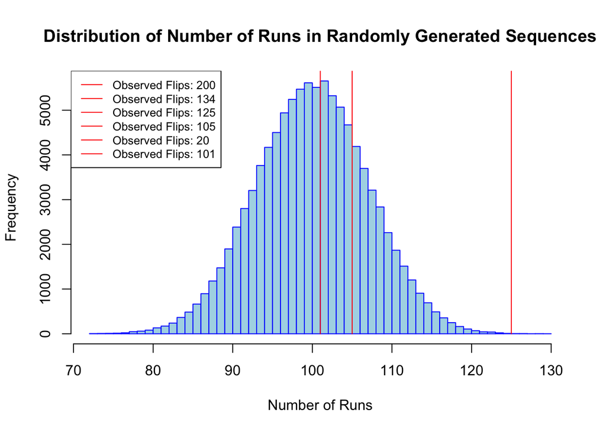

```r
split = function(str) strsplit(str, split="")[[1]]

count_runs <- function(flips) {
  runs <- rle(flips)
  return(length(runs$lengths))
}

simulate_flips <- function(n) {
  flips <- sample(c("H", "T"), size = n, replace = TRUE)
  return(flips)
}

num_runs_simulation <- function(n, num_simulations) {
  runs_count <- replicate(num_simulations, {
    simulated_flips <- simulate_flips(n)
    count_runs(simulated_flips)
  })
  return(runs_count)
}

NMC <- 1e5
num_flips <- nchar(flips1)
runs_distribution <- num_runs_simulation(num_flips, NMC)

calculate_p_value <- function(observed_runs, runs_distribution) {
  less_than_observed <- mean(runs_distribution <= observed_runs)
  greater_than_observed <- mean(runs_distribution >= observed_runs)
  p_value <- 2 * min(less_than_observed, greater_than_observed)
  p_value <- min(p_value, 1)
  return(p_value)
}

sequences <- list(flips1, flips2, flips3, flips4, flips5, flips6)
observed_runs <- numeric(length(sequences))
p_values <- numeric(length(sequences))

for (i in seq_along(sequences)) {
  observed_runs[i] <- count_runs(split(sequences[[i]]))
  p_values[i] <- calculate_p_value(observed_runs[i], runs_distribution)
}

# Generate histogram for visualization
hist(runs_distribution,
     main = "Distribution of Number of Runs in Randomly Generated Sequences",
     xlab = "Number of Runs",
     ylab = "Frequency",
     col = "lightblue",
     border = "blue",
     breaks = 50)

max_freq <- max(hist(runs_distribution, plot = FALSE)$counts)

for (obs_run in observed_runs) {
  lines(x = c(obs_run, obs_run), y = c(0, max_freq * 0.9), col = "red", lwd = 1)
}

legend("topleft", legend = paste("Observed Flips:", observed_runs), col = "red", lty = 1, cex = 0.8)
```

```r
p_values
```

```
## [1] 0.00000 0.00000 0.00042 0.57214 0.00000 1.00000
```

> Test Statistic 2: We count the proportion of heads from the expected proportion under the null hypothesis of a fair coin (which is 0.5).

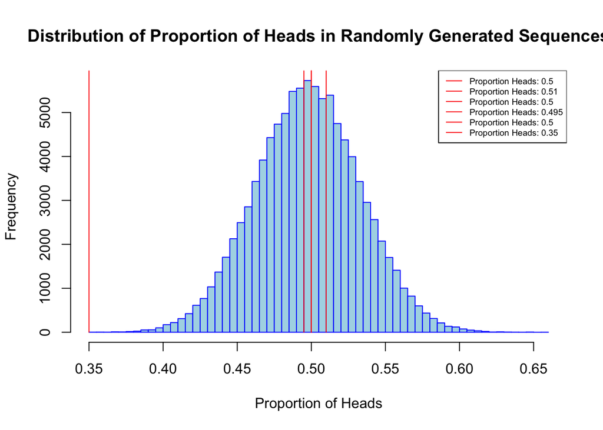

```r
split = function(str) strsplit(str, split="")[[1]]

calculate_proportion_heads <- function(flips) {
  num_heads <- sum(flips == "H")
  proportion_heads <- num_heads / length(flips)
  return(proportion_heads)
}

simulate_flips <- function(n) {
  flips <- sample(c("H", "T"), size = n, replace = TRUE)
  return(flips)
}

simulate_proportion_heads <- function(n, num_simulations) {
  proportions <- replicate(num_simulations, {
    simulated_flips <- simulate_flips(n)
    calculate_proportion_heads(simulated_flips)
  })
  return(proportions)
}

NMC <- 1e5
num_flips <- nchar(flips1)
proportion_heads_distribution <- simulate_proportion_heads(num_flips, NMC)

calculate_p_value <- function(observed_runs, runs_distribution) {
  less_than_observed <- mean(runs_distribution <= observed_runs)
  greater_than_observed <- mean(runs_distribution >= observed_runs)
  p_value <- 2 * min(less_than_observed, greater_than_observed)
  p_value <- min(p_value, 1)
  return(p_value)
}

sequences <- list(flips1, flips2, flips3, flips4, flips5, flips6)
observed_runs <- numeric(length(sequences))
p_values <- numeric(length(sequences))

for (i in seq_along(sequences)) {
  observed_runs[i] <- calculate_proportion_heads(split(sequences[[i]]))
  p_values[i] <- calculate_p_value(observed_runs[i], proportion_heads_distribution)
}

# Generate histogram for visualization
hist(proportion_heads_distribution,
     main = "Distribution of Proportion of Heads in Randomly Generated Sequences",
     xlab = "Proportion of Heads",
     ylab = "Frequency",
     col = "lightblue",
     border = "blue",
     breaks = 50)

max_freq <- max(hist(proportion_heads_distribution, plot = FALSE)$counts)

for (obs_run in observed_runs) {
  lines(x = c(obs_run, obs_run), y = c(0, max_freq * 0.9), col = "red", lwd = 1)
}

legend("topright", legend = paste("Proportion Heads:", observed_runs), col = "red", lty = 1, cex = 0.6)
```

```r
p_values
```

```
## [1] 1.00000 0.83598 1.00000 0.93764 1.00000 0.00004
```

> Test Statistic 3: We count the alternation rate between heads and tails. A truly random sequence from a fair coin would have a balance between persistence (repeated heads or tails) and alternation.

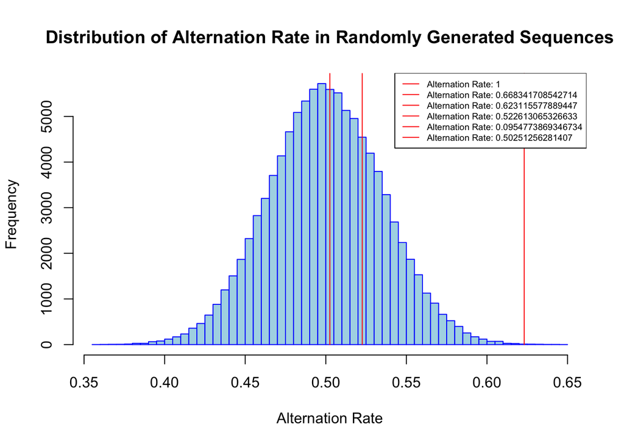

```r
split = function(str) strsplit(str, split="")[[1]]

calculate_alternation_rate <- function(flips) {
  changes <- sum(diff(flips == "H") != 0)
  total_changes_possible <- length(flips) - 1
  alternation_rate <- changes / total_changes_possible
  return(alternation_rate)
}

simulate_flips <- function(n) {
  flips <- sample(c("H", "T"), size = n, replace = TRUE)
  return(flips)
}

simulate_alternation_rates <- function(n, num_simulations) {
  rates <- replicate(num_simulations, {
    simulated_flips <- simulate_flips(n)
    calculate_alternation_rate(simulated_flips)
  })
  return(rates)
}

NMC <- 1e5
num_flips <- nchar(flips1)
alternation_rate_distribution <- simulate_alternation_rates(num_flips, NMC)

calculate_p_value <- function(observed_runs, runs_distribution) {
  less_than_observed <- mean(runs_distribution <= observed_runs)
  greater_than_observed <- mean(runs_distribution >= observed_runs)
  p_value <- 2 * min(less_than_observed, greater_than_observed)
  p_value <- min(p_value, 1)
  return(p_value)
}

sequences <- list(flips1, flips2, flips3, flips4, flips5, flips6)
observed_runs <- numeric(length(sequences))
p_values <- numeric(length(sequences))

for (i in seq_along(sequences)) {
  observed_runs[i] <- calculate_alternation_rate(split(sequences[[i]]))
  p_values[i] <- calculate_p_value(observed_runs[i], alternation_rate_distribution)
}

# Generate histogram for visualization
hist(alternation_rate_distribution,
     main = "Distribution of Alternation Rate in Randomly Generated Sequences",
     xlab = "Alternation Rate",
     ylab = "Frequency",
     col = "lightblue",
     border = "blue",
     breaks = 50)

max_freq <- max(hist(proportion_heads_distribution, plot = FALSE)$counts)

for (obs_run in observed_runs) {
  lines(x = c(obs_run, obs_run), y = c(0, max_freq * 0.9), col = "red", lwd = 1)
}

legend("topright", legend = paste("Alternation Rate:", observed_runs), col = "red", lty = 1, cex = 0.6)
```

```r
p_values
```

```
## [1] 0.00000 0.00000 0.00070 0.57074 0.00000 0.99464
```

## Problem #2: Finding the Trick Coin (6 pts; 2pts each)

I have two coins in my pocket - a trick coin with two heads and a fair coin with one head and one tail(s?). We’ll play a game. I will grab one coin at random, and flip it $N$ times. After that you will have to decide if it is the fair coin or the trick coin. The null hypothesis is that it is the fair coin.

**Decision Rule 1**: If after $N$ flips there are no tails, then you decide it is the trick coin. If there is at least 1 tail then you know it is the fair coin.

1. Using “Decision Rule 1”, what is the lowest number of flips $N$ would you need in order to have a significance level less than 5% for this test?
- We want to find the smallest N where $(\frac{1}{2})^N < 0.05$.

```r
N <- log(0.05)/log(0.5)
N
```

```
## [1] 4.321928
```

- So $N = 5$
2. Using $N$ from part a, what is the power of the test?
- Power is correctly rejecting the null hypothesis. So this means correctly identifying the trick coin.
- With $N$ flips, since the trick coin always lands heads, the probability of deciding it’s the trick coin (correctly rejecting the null hypothesis) is 100% regardless of $N$, because you will never observe a tail. This means that the decision rule (no tails observed) will always lead us to correctly reject the null hypothesis when the trick coin is used.
3. Suppose $N=4$ is decided. How can you modify the decision process to have a significance level of exactly 5%? Does this change the power of the test?
- If no tails are observed, perform an additional random determination (such as drawing from a bag with 95 fair items and 5 marked as “trick”) to decide if the coin is the trick coin. This additional step is only triggered if all flips are heads, adding a 5% chance of deciding it’s the trick coin under this specific condition.
- This adjusted decision process ensures that, even if all heads are observed with a fair coin, there’s only a 5% chance of incorrectly deciding it’s the trick coin, meeting the desired significance level.
- The power remains high for detecting the trick coin since, in all cases where the trick coin is used, the initial condition (all heads) will always be met. The additional random determination does not reduce the power because it’s only applied when the initial condition (suggestive of the trick coin) is met.
4. Extra Credit (2 points): Suppose if you guess correct you win $100 (and if you’re wrong you get nothing), but each flip of the coin costs $10. What strategy would you use to maximize your expected profit from this game?
- The strategy involves balancing the cost of flips against the probability of correctly guessing the coin type to maximize expected profit. With each flip costing $10, the key is to minimize the number of flips while still being reasonably sure you can make the correct guess.
- If N=5: You would flip the coin up to 5 times. If you see no tails, you guess the trick coin, but each flip reduces your profit by $10.
- Maximizing Profit:
  - Flip fewer times to increase profit margin but balance this with the risk of making an incorrect guess.
  - Given the decision rule and payouts, flipping the coin fewer times (close to the calculated N for a desired significance level) might be optimal, provided you’re willing to accept the calculated risk level.
- For N=4 and aiming for a strategy that maximizes expected profit:
  - Start by flipping the coin. If a tail is observed within the first few flips, you can conclude it’s the fair coin with minimal cost.
  - If no tails are observed after a certain number of flips, consider stopping based on the cumulative cost and the remaining potential profit.

## Problem #3: Testing the maximum of a uniform distribution (8 pts; 2 pts each)

We sample $X_1, X_x,\ldots,X_n \overset{\text{iid}}\sim\text{Uniform}(0,m)$ where $m$ is an unknown maximum. Sleazy Jim tells you that $m=1$ but you’re not so sure. The 50 values sampled are in the following data file:

```r
X <- read.csv("uniform_sample.csv")$x

X
```

```
##  [1] 0.343246125 0.845331763 0.684962514 0.169305117 0.200210369 0.356923825
##  [7] 0.618709566 0.356788725 0.463665448 0.140930417 0.371956468 0.290623483
## [13] 0.913263779 0.009077785 0.224780933 0.042212803 0.765213745 0.234971749
## [19] 0.110230761 0.356156177 0.753888071 0.245138641 0.377871093 0.591001945
## [25] 0.718874781 0.460685407 0.723332535 0.467167955 0.805576242 0.105145157
## [31] 0.332226258 0.282394464 0.367354850 0.591933796 0.548251072 0.014293113
## [37] 0.706164011 0.407966349 0.712363180 0.153611100 0.043375899 0.856637282
## [43] 0.565973643 0.944338254 0.099868015 0.810696513 0.497407495 0.023248688
## [49] 0.181430286 0.341202305
```

1. Write out in formal notation the null and alternative hypotheses.
- Null Hypothesis: The null hypothesis states that the maximum m of the uniform distribution is exactly 1, as claimed by Sleazy Jim. $H_{0}: m = 1$
- Alternative Hypothesis: The alternative hypothesis suggests that the maximum m of the uniform distribution is less than to 1, indicating skepticism towards Jim’s claim. $H_{a}: m \lt 1$

> After observing the values in X, we note that every value in X is less than 1. Therefore, we should have our alternative test to observe if the max is less than 1.
2. Come up with a test statistic and measure your sampled data. Is this a one-sided test or two-sided test?
- Given that we’re dealing with a uniform distribution and questioning the maximum value m, a natural test statistic to use is the maximum value observed in your sample, max(X). This statistic is sensitive to changes in the maximum value of the distribution, making it suitable for the task at hand.
- Given the nature of my alternative hypothesis ($m < 1$), the test I am proposing is a one-sided test. Specifically, it’s a left-tailed test because I am interested in determining if the true maximum ($m$) of the uniform distribution is less than the proposed value of 1.
3. Simulate a distribution for the test statistic under the null hypothesis of size at least 1000. Display a histogram of your test statistic distribution.

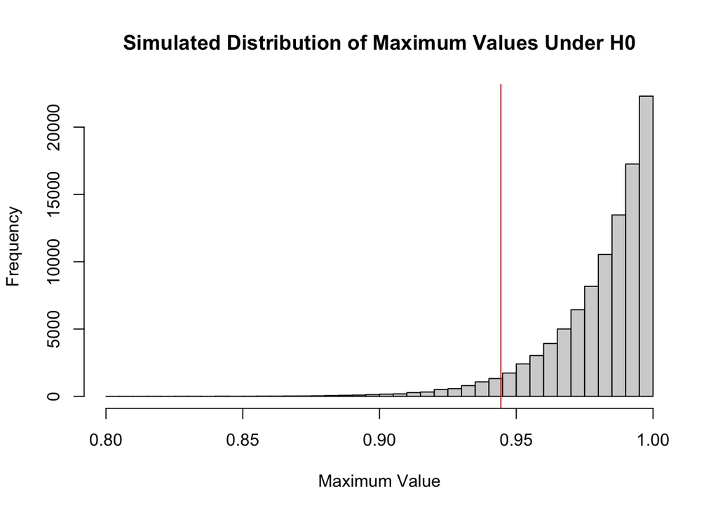

```r
n <- 50
num_simulations <- 100000
simulated_max_values <- replicate(num_simulations, max(runif(n, 0, 1)))

hist(simulated_max_values, breaks=30, main="Simulated Distribution of Maximum Values Under H0", xlab="Maximum Value")

observed_max <- max(X)
abline(v = observed_max, col = "red")
```

4. Calculate the $p$-value for this data and make a conclusion.

```r
p_value_lower <- sum(simulated_max_values <= observed_max) / num_simulations

p_value_lower
```

```
## [1] 0.05546
```

## Problem #4: Rising Temperatures? (10 pts; 2 pt each)

The `annual_avg_temp.csv` data file contains the US annual average temperature from 1875 through 2022.

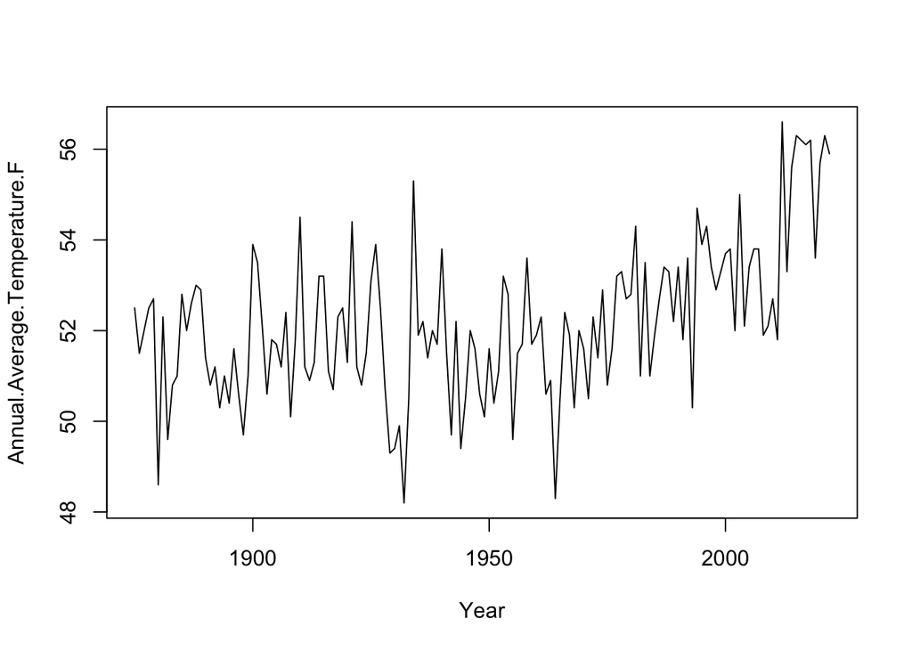

```r
temp <- read.csv("annual_avg_temp.csv")
temps <- temp$Annual.Average.Temperature.F
plot(temp, type="l")
```

There seems to be a trend but it could be due to randomness. Your task is to perform a permutation test on the historical record of annual avg. temperatures to determine if there is statistical evidence of a real trend.

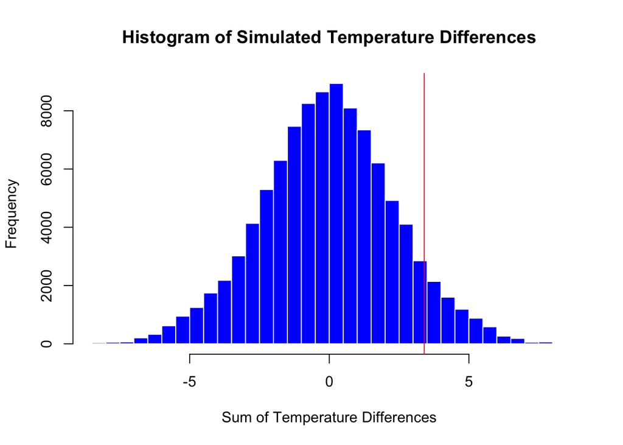

```r
calculate_temp_differences <- function(temps) {
  temp_diffs <- diff(temps)

  return(sum(temp_diffs))
}

NMC <- 1e5

temps_distribution <- numeric(NMC)
for (i in 1:NMC) {
  sampled_temps <- sample(temps)
  temps_distribution[i] <- calculate_temp_differences(sampled_temps)
}

hist(temps_distribution, breaks = 50, col = "blue", border = "white",
     main = "Histogram of Simulated Temperature Differences",
     xlab = "Sum of Temperature Differences", ylab = "Frequency")

observed_sum <- calculate_temp_differences(temps)
abline(v = observed_sum, col = "red")
```

5. Calculate the test statistic on the observed data, calculate the $p$-value and state your conclusions.

```r
p_value_upper <- mean(temps_distribution >= observed_sum)

p_value_upper
```

```
## [1] 0.08011
```

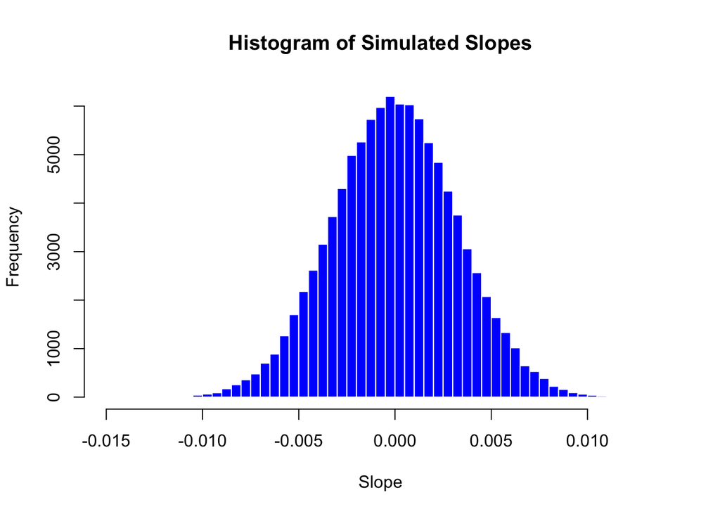

```r
years <- temp$Year

calculate_slope <- function(temps, years) {
  lm_model <- lm(temps ~ years)
  return(coef(lm_model)[2])
}

NMC <- 1e5

slope_distribution <- numeric(NMC)
for (i in 1:NMC) {
  sampled_temps <- sample(temps)
  slope_distribution[i] <- calculate_slope(sampled_temps, years)
}

hist(slope_distribution, breaks = 50, col = "blue", border = "white",
     main = "Histogram of Simulated Slopes",
     xlab = "Slope", ylab = "Frequency")

observed_slope <- calculate_slope(temps, years)
abline(v = observed_slope, col = "red")
```

```r
p_value <- mean(abs(slope_distribution) >= abs(observed_slope))

p_value
```

```
## [1] 0
```

- This time around, we get a p-value of 0. A p-value of 0 in this context suggests that none of the permuted datasets produced a slope as extreme as the observed slope from the actual data. This result indicates very strong evidence against the null hypothesis, suggesting that the observed trend in temperatures is highly unlikely to be due to random chance.

*Hint: basing the test statistic on the differences between consecutive years may be a good idea.*